# PAM Booster: Administration Guide

Radiant Logic

# General Principles

## Introduction

PAM Booster maps and monitors of the evolution of risks related to privileged accounts.  
The PAM Booster has been designed for CyberArk environments based on Active Directory, EntraID or other LDAP environments.  
Based on a snapshot of the information system, including HR, Active Directory, EntraID or LDAP and CyberArk data, PAM Booster creates a 360-degree view of identities and assets accessed through privileged accounts.

The service provides checks on privileged accounts, the CyberArk configuration as well as access in relation to the security policy. Remediation advice is given and may target the privileged accounts, CyberArk access configuration or the structure of Active Directory, EntraID or your LDAP repository.

PAM Booster is now part of the Identity Analytics project by default (IAP2.0 and upper), and is activated by the license key. Note that before launching an execution plan, you need to set the variable “isPamBoosterActive” to “true” in the technical configuration of the project. This way, all controls and metadata will be computed.

This documentation is intended for the administrator of PAM Booster. The features presented here are the following:

- Extraction and upload of data to the Identity Analytics platform, and
- Management of users who can access the service

## Process Support

The service has been designed to assist with any PAM Booster project using CyberArk PAM, Privileged Cloud and Entra ID, Active Directory or LDAP. Please note with CyberArk Privilege Cloud, roles mapping with CyberArk Identity are not supported, only groups are.

## Graphic Environment

The PAM Booster is meant to be used in full screen mode with a resolution of 1920 x 1024. It is possible to use it with a lower resolution, however some screens may show scroll bars as a result.

# Data Preparation

## Data Source

The PAM Booster must be supplied with up to date entitlements in order to be able to conduct relevant analyses. This chapter specifies the nature of the information required by the service and how to obtain it. The importance of data quality is highlighted here as it is a key pillar in the success of the project.

### Nature of the Data

The PAM Booster uses three information sources:

- Data regarding identities designated by the term “HR” (Human Resources) in the documentation,
- CyberArk PAM and/or CyberArk Privilege Cloud data
- Repository Data from the LDAP directories referenced by CyberArk (ex: Active Directory, EntraID, OpenLDAP…)

Human Resource data is crucial in identifying employee characteristics such as their organization or job and helps understand the relevance of entitlements.

### The Concept of Identity

Physical people are referred to as identities. Each identity has one or more user accounts giving access to CyberArk. The rights that the person has within CyberArk are associated with the account.

An entitlement means that a person has access to a set of functions within CyberArk. For example, an identity may have a user account in Active Directory belonging to a group giving the right to use the credentials of 3 safes.

A permission refers to a basic operation in CyberArk like `useAccount` or `retieveAccount`, permissions to access the target system.

### Data Quality

Data quality covers the following aspects:

- Completeness
- Accuracy.

Completeness means that all the information is available. Here are a few examples:

- Are the identities attached to organizations?
- Are contractors included?
- Are the department managers known?
- Are all the domains of Active Directory present (in a multi-domain architecture)?
- Do all of the accounts have an owner?

Accuracy means that the information is up to date. Here are a few examples:

- Do the job titles of the identities reflect their activities?
- Are the organizational attachments up to date?
- Are the owners of the accounts the right ones?
- Are all account statuses valid (active/disabled)?
- Is the identity type correct (employee/contractor)?

### Data Origin

The PAM Booster is powered by providing import files for different data sources, such as HR, Active Directory, LDAP directories… The platform expects a shared folder containing all these extractions.

Regarding the HR data, it is important to integrate both employees and contractors into the analysis. Employees are often managed in an HR database that must be extracted. Contractors are often included in Active Directory, although this is not a firm rule. If an extraction from the HR database is possible, this would be optimal, as the completeness of the information will allow for successful analysis. If it is not possible to retrieve an extraction from the HR database, then both employees and contractors can be taken from Active Directory. For the list of contractors, it is possible to extract it from any other repository that contains this information if it is not readily available in Active Directory.

In summary, the typical data sources for HR data are as follows:

- Employees:
  - HR Database
  - Active Directory
- Contractors:
  - Active Directory
  - Other repository

When the HR source is Active Directory, the script provided by the active directory add-on is able to perform the extraction. It extracts all the accounts and consider them as identities. You may activate options to filter service or technical accounts to prevent creating wrong identities. In all other cases, the application manager will need to generate an export of the people and their characteristics (organization, job, employee type, etc.).

## Extractions

RadiantLogic offers an add-on named `bw_ias_cyberark` that contains the PowerShell script called `ExtractCA.ps1` to help extract the following data:

- CyberArk vaults
- CyberArk safes
- CyberArk accounts secured in the safes
- Users and groups

The script `ca_identity.ps1` helps to extract the following data :

- CyberArk Identity Users
- CyberArk Identity Roles
- CyberArk Identity Organizations
- CyberArk Identity Directory Services

> **Note:** The PowerShell script is signed and any modification of the script will make it ineffective unless the local security parameters are changed in order to authorize the execution of unsigned scripts. Please note that this modification can lead to potential risk.

> **Note:** The version 1.2 of the `bw_ias_cyberark` add-on has to be used, older versions are deprecated. If you upgrade an older version of this add-on, note that since the safe code computation has changed, the safes will be re-created with another key and as a result you’ll get duplicates.

When creating the ZIP file, the PowerShell script also adds some files generated by other processes. This is done using a configuration file in JSON format. This configuration file describes all the data sources to be included in the ZIP file.

The PowerShell scripts `ExtractCA.ps1` and `ca_identity.ps1` are available in the following folder of your project: /extractors/bw_ias_cyberark/CyberArk.

### Prerequisites

The script requires the following prerequisites in order to run:

- PowerShell 5.1 or greater
- .NET Framework 4.5 or greater

#### Prerequisites for extracting Active Directory

The Active Directory needs to be executed using a domain user account with at least “read” privilege on attributes.

#### Prerequisites for extracting CyberArk PAM or Privilege Cloud

The CyberArk extraction requires the following prerequisites:

- For CyberArk Privilege Cloud, a CyberArk user for REST API calls with the following credentials:
  - `ManageDirectoryMapping` and `AuditUsers` vault authorization
  - User is a member of the `Vault Admins` builtin group.
  - User is a member of the `Auditors` builtin group.
- For CyberArk PAM on-premise, the Export Vault Data (EVD) **Utility** must be installed on the platform performing the extraction.
- A CyberArk user for EVD extraction with the following credentials:
  - `AuditUsers` vault authorization
  - User should be part of **Auditors** builtin group

#### Prerequisites for extracting CyberArk Identity

The CyberArk Identity service requires the following prerequisites:

- A CyberArk Identity user for REST API calls with the following credentials:
  - User is part of a role with `OAuth2 Client` as Assigned Application

### Methodology for the extractions

The first step is to identify all the sources to be extracted:

- what are the vaults to extract? You will need to set up an extraction per vault.
- Which directories are referenced in each vault? Are the directories of type Active Directory? Each directory will have to be extracted to retrieve users and groups.
- where are the data sources to find organizational information about employees and contractors?

The second step is to decide with which account to perform the extractions on the platform. This choice has to be made now. The extraction script can be launched manually in a command window or automatically in the Windows Task Scheduler or any other task launching tool. The different extractions (CyberArk and Active Directory) require credentials that need to be encrypted on the extraction platform. The encryption depends on the account used and the machine. If you perform all credential encryption operations with a personal account, the extraction script will only work if it is run with this same account (to allow it to decrypt the credentials). Once the configuration has been fine-tuned, it is a good idea to add the script to the Windows task scheduler to run it on a regular basis (once a week for example). If a service account is used for this automatic launch, the script will fail because it will not be able to decrypt the credentials that have been encrypted with the personal account. All credentials will have to be re-encrypted with this service account.

It is therefore preferable to encrypt all credentials with the service account from the start. To do this, all the operations described in this documentation must be performed in a powershell linked to the service account using the following command (example with the login user1 from ACME domain):

```
runas.exe /user:ACME\user1 powershell
```

The third step is to set up all the extractions following the documentation. Generally speaking, this consists in encrypting the credentials that will be used:

- set up the credentials for CyberArk and then the extraction configuration.
- if Active Directory is the directory CyberArk relies on, set the credentials for the Active Directory extraction and then configure the extraction.
- Prepare the HR extraction either from an HR source or using Active Directory if no HR source is available.

The fourth step is to launch the collect of your RadiantOne Identity Analytics project. You can then browse the portal to check the data quality.

The fifth step is to automate the data upload to your IAP platform using a task scheduler.

The final step is to schedule also the execution every week. To do this, you need to add the execution of the `ExtractCA` command to the task scheduler.

### CyberArk extractions

The script `ExtractCA.ps1` supports the extraction of CyberArk data. The script performs the extraction in read-only mode (no modification to the CyberArk configuration or data). The script does **NOT** extract any passwords or credentials. The extracted data contains the user rights (who can change the configuration, who can use a credential).

The script can use both the CyberArk Rest API and the EVD tool. It offers 3 modes:

- `RestAPI-only`: Use of CyberArk Rest API.
- `EVD-only`: Use of Export Vault Data (EVD) **Utility** (**highly recommended**).
- `Mixed-mode`: Use both Rest API and EVD.

The EVD-only mode **should** be used for CyberArk PAM, RestAPI-only for CyberArk Privilege Cloud. The following chapters describe the operations of mixed mode configurations (using both EVD and REST API) to present you both methods.

> **Warning:** A limitation in CyberArk causes the *Get group **API not to extract group members when using a verion pre 12.2. A workaround is to use the attribute groupsMembership of the** Get users** API. However, when using RestAPI-Only mode, recursive group memberships are note handled.

#### Preparing extractions

The first step is to check the REST API configuration in PVWA. By default REST API is allowed to export only 20000 accounts. These limit should be adjusted depending on your configuration. For example, if your vault contains 42 000 credentials, you should set the limit to 50 000.

To increase this limit, open PVWA web application and go to: 1. Configuration Options (Administration) 2. Options 3. PIM Suite Configuration > Accounts UI Preferences > Main > Views Settings > MaxDisplayedReco0rds 4. Increase the default value (for example 50 000)

[figure not shown]

The second step is to add a first user for the REST API. In PVWA, add a CyberArk user with these settings: * `ManageDirectoryMapping` and `AuditUsers` vault authorization * User is a member of the `Vault Admins` builtin group. * User is a member of the `Auditors` builtin group. In this documentation, this user is called `bw_rest_user`.

The third step is to add a second user for EVD with these settings: * `AuditUsers` vault authorization * User should be part of **Auditors** builtin group In this documentation, this user is called `bw_evd_user`.

The fourth step is on the extraction platform * install EVD tool if not already installed and configure the `vault.ini` file inside the installation folder.

The fifth step if to create a credential file for `bw_rest_user`. Make sure to replace `bw_rest_user` by the name of the REST API user. A dialog box appears and you are invited to type the password:

```
Get-Credential -UserName bw_rest_user -Message "Credential" | Export-CliXml bw_rest_user.xml
```

> **Note:** Do not forget to run the command in a powershell on the behalf of a service account.

The seventh step is to create a credential file for bw_evd_user. Make sure to replace bw_evd_user by the name of the EVD user. Change Password01 in the following command with the right password:

```
.\CreateCredFile.exe bw_evd_user.cred password /username bw_evd_user /password Password01
```

The last step is to edit the `config.json` section to activate and adapt the CyberArk section. This is described in the next charpter.

#### CyberArk Extraction Parameters

Some options are available to change the behaviour of the extraction:

**Option**

**Description**

mode

vaultName

The name of the vault will be used to prefix the generated files and verify the application and repository names during the data loading.

EVD_location

The Export Vault Data (EVD) **Utility** location is mandatory for `EVD-only` and `Mixed-mode`.

EVD_config

The EVD configuration file name will be by default `vault.ini` and mandatory for `EVD-only` and `Mixed-mode`. The configuration file must be located in the EVD root folder and should contain at least the following attributes:

- `VAULT`: Vault name (ex:“Demo Vault”)
- `ADDRESS`: Vault IP address (ex:34.240.160.22)
- `PORT`: Vault port number (ex:1858)

EVD_cred

The credential file name, mandatory for `EVD-only` and `Mixed-mode`, should be created using the **CreateCredFile.exe** CyberARk Utility and must be located in the EVD root folder.

logNumOfDays

The number of previous days that will be included in the Safe and user log activities report. The default number is 45.

PVWAURL

PVWA url, example: `https://<IIS_Server_Ip>/PasswordVault` (Mandatory for `RestAPI-only` and `Mixed-mode`)

AuthType

The type of user credentials can be Cyberark for a `CyberArk` user or LDAP for an `LDAP` user (example: ActiveDirectory).

credential

A file containing PSCredential is used to extract objects in CyberArk. See the example to create and store PSCredential objects in a file. (Mandatory for `RestAPI-only` and `Mixed-mode`)

skipCertificateCheck

Set to `1` if the script is executed under PowerShell 7, `0` by default (work on PowerShell 5.1).

exportDetails

Set to `False` to disable the export of additional user information such as `expiryDate`, `lastSuccessfulLoginDate`,`passwordNeverExpires`. By default, these are set to `True`. If the vault contains many users, the `-exportDetails=True` can cause performance issues due to the number of REST queries to execute.

LDAPConfigFile

Config file containing GroupRecursiveSearch flag for each LDAP directory declared in the Vault. It can be either CSV or XML file, See examples for more details, by default GroupRecursiveSearch is disabled, if you use default CyberArk profiles(GroupRecursiveSearch is disabled) in this case there is no need to set this parameter.

- `CSV`: Manuel file create and maintained by extraction responsible.
- `XML`: Exported file (LDAPConf.xml) from CyberArk portal PVWA.

logLevel

This parameter allows to specify a log level. Possible values are:

- Error
- Warning
- Info
- Debug

The default value is `Error`.

errAction

Specify the action to perform if an error occur. The possible values are:

- Continue
- SilentlyContinue
- Stop

The default value is `Stop`.

> **Important:** by defaultin LDAP CyberArk configuration the GroupRecursiveSearch propety is disabled, if you use default CyberArk profiles with `GroupRecursiveSearch=No` on all your LDAP profiles please ignore the `LDAPConfigFile` parameter otherwise follow the next procedure. Only one file is needed, it can be a manual created CSV file or an XML file exported from CyberArk PVWA portal

> **Note:** `Tenant_ID` field is only needed with CyberArk Cloud

##### Credentials Secured by Powershell Example

The following commands are necessary to create the PSCredential and store it in a file (the password will be encrypted by the PowerShell API). The generated file will only work using the local machine and user session where it was created.

```
$pwd=ConvertTo-SecureString --String $Password --AsPlainText -Force
$credential=New-Object --TypeName System.Management.Automation.PSCredential --ArgumentList "extract-user", $pwd
```

```
$credential = Get-Credential -UserName extract-user
$credential | Export-CliXml credential.xml
```

##### EVD Credentials File Creation Example

This is a command example of how to create a EVD cred file using the CreateCredFile tool and should be executed under the EVD root folder.

```
.\CreateCredFile.exe user.cred password /username extract-user /password Password01
```

##### EVD-only Extraction Example

This is a command example to extract CyberArk data using EVD-only.

```
./ExtractCA.ps1 -mode EVD-only -vaultName Vault -EVD_location C:\Applications\EVD -EVD_config Vault.ini -EVD_cred evd.cred -logLevel Debug
```

##### RestAPI-only Mode Extraction Example

This is a command example to extract CyberArk data using the RestAPI-only.

```
./ExtractCA.ps1 -mode RestAPI-only -vaultName Vault -PVWAURL https://IP/PasswordVault -credential C:\Applications\credential.xml -logLevel Debug
```

##### Mixed Mode Extraction Example

This is a command example to extract CyberArk data using the Mixed-mode (Rest + EVD).

```
./ExtractCA.ps1 -mode Mixed-mode -vaultName Vault -PVWAURL https://IP/PasswordVault -credential C:\Applications\credential.xml -EVD_location C:\Applications\EVD -EVD_config Vault.ini -EVD_cred evd.cred -logLevel Debug
```

#### CyberArk Extraction Expected Results

Depending on the parameter `-mode`, the CyberArk script generates the following CSV files:

- `RestAPI-only`
  - `{VaultName}_groups.csv`: contains groups details. A group can be in CyberArk or LDAP (ActiveDirectory).
  - `{VaultName}_users.csv`: contains users details and their group membership. A user can be in CyberArk or LDAP (ActiveDirectory).
  - `{VaultName}_ldapdirectories.csv`: contains list of LDAP directories configured in the vault.
  - `{VaultName}_ldapmapping.csv`: contains LDAP groups and their authorizations to the vault and the related group recursivity parameter.
  - `{VaultName}_accounts.csv`: contains the privileged account details and in which safe they belong.
  - `{VaultName}_safes.csv`: contains safe details.
  - `{VaultName}_safemembers.csv`: contains the mapping between safes, users/groups and authorizations.
  - `{VaultName}_export-mode.csv`: contains the extraction mode (`RestAPI-only`).
- `EVD-only`
  - `{VaultName}_EVD-UsersList.csv`: contains user details. A user can be in CyberArk or LDAP (ActiveDirectory).
  - `{VaultName}_EVD-GroupMembersList.csv`: contains group membership.
  - `{VaultName}_EVD-GroupsList.csv`: contains groups details. A group can be in CyberArk or LDAP (ActiveDirectory).
  - `{VaultName}_EVD-SafesList.csv`: contains safe details.
  - `{VaultName}_EVD-OwnersList.csv`: contains the mapping between safes, users/groups and authorizations.
  - `{VaultName}_EVD-FilesList.csv`: contains the privileged account details and in which safe they belong.
  - `{VaultName}_EVD-LogList.csv`: contains the Safe and user log activities report.
  - `{VaultName}_EVD-ObjectProperties.csv`: contains information about the safe configuration.
  - `{VaultName}_ldapdirectories.csv`: contains list of LDAP directories configured in the vault and the related group recursivity parameter.
  - `{VaultName}_export-mode.csv`: contains the extraction mode (`EVD-only`).
- `Mixed-mode`
  - `{VaultName}_EVD-UsersList.csv`: contains user details. A user can be in CyberArk or LDAP (ActiveDirectory).
  - `{VaultName}_EVD-GroupMembersList.csv`: contains group membership.
  - `{VaultName}_EVD-GroupsList.csv`: contains group details. A group can be in CyberArk or LDAP (ActiveDirectory).
  - `{VaultName}_EVD-OwnersList.csv`: contains the mapping between safes, users/groups and authorizations.
  - `{VaultName}_EVD-SafesList.csv`: contain safes details
  - `{VaultName}_EVD-LogList.csv`: contains the the Safe and user log activities report.
  - `{VaultName}_ldapdirectories.csv`: contains list of LDAP directories configured in the vault and the related group recursivity parameter.
  - `{VaultName}_ldapmapping.csv`: contains LDAP groups and their authorizations to the vault.
  - `{VaultName}_accounts.csv`: contains the privileged account details and in which safe they belong.
  - `{VaultName}_safes.csv`: contains safes details.
  - `{VaultName}_users.csv`: contains users details and their group membership. A user can be in CyberArk or LDAP (ActiveDirectory).
  - `{VaultName}_export-mode.csv`: contains extraction mode (`Mixed-mode`).

The script also produces a log file. This file is named `ExtractCA_{timestamp}.log` and contains details of extractions according to the `-LogLevel` parameter.

### CyberArk Identity extractions

The script `ca_identity.ps1` supports the extraction of CyberArk Identity data. The script performs the extraction in read-only mode (no modification to the CyberArk Identity configuration or data). The script does **NOT** extract any passwords or credentials. The extracted data contains the user details (name, phonenumber, email…).

> **Warning:** If there is no CyberArk Identity, make sure to remove `$Identity_Tenant_URL` in `config.json` and do not put ’_’ in the destination folder name `"folder": XXX`

#### Preparing extractions

The first step is to have a service user assigned to `OAuth2 Client` application

The second step is to have `System Administrator` role with the same user

The third step if to create a credential file for `bw_identity_user`. Make sure to replace `bw_identity_user` by the name of the Identity service user. A dialog box appears and you are invited to type the password:

```
Get-Credential -UserName bw_identity_user -Message "Credential" | Export-CliXml bw_identity_user.xml
```

> **Note:** Do not forget to run the command in a powershell on the behalf of a service account.  
> Use the same service account as the one used for the PCloud extraction.

The last step is to edit the `config.json` section to activate and adapt the CyberArk section.

#### CyberArk Identity Extraction Parameters

- `-Identity_Tenant_Url` Tenant URL, example: `https://<TenantID>.id.cyberark.cloud`
- `-CredentialFilePath` A file containing PSCredential is used to extract objects in CyberArk Identity. See the example to create and store PSCredential objects in a file.
- `-outputDirectory` The path to the output directory where extracted files will be stored.

#### CyberArk Identity Extraction Example

This is a command example to extract CyberArk Identity data.

```
.\ca_identity.ps1 -Identity_Tenant_URL "https://<Tenant_ID>.id.cyberark.cloud" -CredentialFilePath <filepath>
```

#### CyberArk Identity Expected Results

- `Identity_CDUser.csv`: contains all users who are enrolled in the Cloud user service.
- `Identity_DirectoryServices.csv`: contains all directory services details.
- `Identity_DSGroups.csv`: contains the groups from all directory services used by the tenant.
- `Identity_DSUsers.csv`: contains users from all directory services used by the tenant.
- `Identity_OrgAdmin.csv`: contains organizations administrators.
- `Identity_Organizations.csv`: contains organizations details.
- `Identity_Repository_Mapping.csv`: contains default Cloud Directory mapping.
- `Identity_RoleMembers.csv`: contains roles membership.
- `Identity_Roles.csv`: contains roles details.
- `Identity_RolesAdminRights.csv`: contains rights of roles
- `Identity_Users.csv`: contains all users who are used in the Cloud user service.

The `Identity_Repository_Mapping.csv` file is a mapping file which needs to be configured manually.  
It provides the code of the repository collected from CyberArk in the column `identityrepo` with the correspondance to the code of the related repository uploaded in Identity Analytics in the column `entraidrepo`. In the `identityrepo` row, add the name of each external repository as defined in Identity Analytics, which means `AAD` for EntraID and `CDS` for CyberArk Identity.  
In the `entraidrepo` row, add the name of the file (without extension `*.ldif`) extracted by the CyberArk PCloud and EntraID extractor scripts, that will be use as repository code in Identity Analytics.  
As a result:  
- There is a `CDS;CAIdentity` line by default in the file, replace `CAIdentity` by `CA{prefix of Identity files}` (e.g. Identity when Identity_CDUser.csv).  
- If you have EntraID extractions, update the `AAD` line with `AAD;name of the file without *.ldif extension`.  
If you have several EntraID environments, you can add each of the environments in separate rows. For example:

```
identityrepo;entraidrepo
CDS;CAIdentity
AAD;bwpreprod
AAD;bwprod
```

#### LDAP Extraction Examples

**Export CyberArk LDAP configuration information for `LDAPConfigFile` Parameters:**

**CSV configuration file:**

This is an example of a CSV configuration file for parameter `-LDAPConfigFile`, this file should have: * UTF8 encoding * Semicolon delimiter * CSV header are `domainName` and `groupRecursiveSearch` * `domainName`: domain name of LDAP directory as declared in CyberArk Vault * `groupRecursiveSearch`: Group Recursive Search flag in LDAP profile(ex: `MicrosoftADProfile.ini`) corresponding to your directory, acceptable values are `Yes`/`No`

[figure not shown]

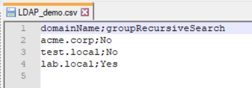

To get `DomainName` of each Directory from CyberARk portal PVWA, follow these steps:

- Open PVWA portal then go to Administration, LDAP Integration, LDAP, Directories.
- Under Directories you will find all declared domains, for each directory take `DomainName` value and put it in the CSV file at column `domainName`

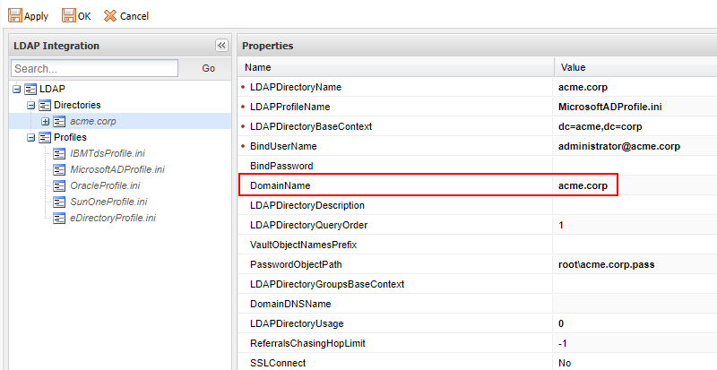

To get groupRecursiveSearch of each Directory DomainName from CyberARk portal PVWA, follow these steps:

- Open PVWA portal then go to Administration, LDAP Integration, LDAP, Directories.
- Under Directories you will found all declared domains, for each directory take `LDAPProfileName` value(ex:MicrosoftADProfile.ini)
- Under Profiles open the `LDAPProfileName` found in previous step and search for `GroupRecursiveSearch` entry, take the found value and put it in the CSV file at column `groupRecursiveSearch` for the corresponding `domainName`

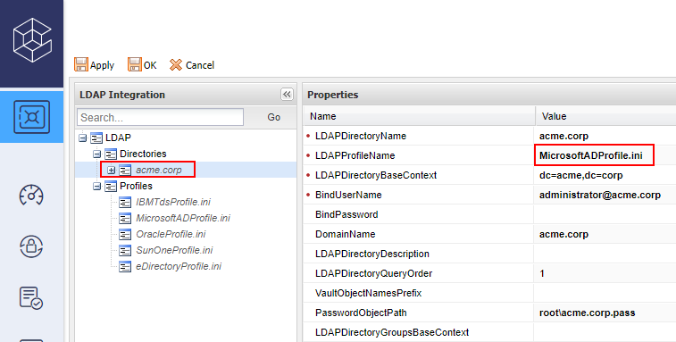

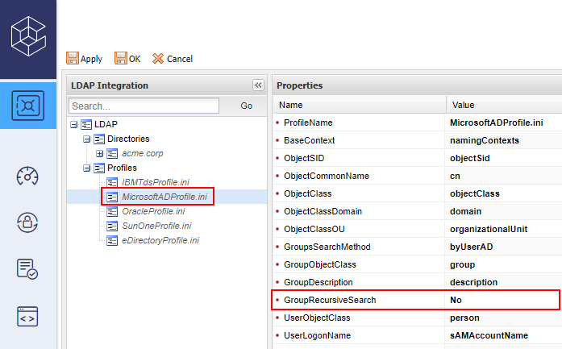

**XML configuration file:**

This is an example of exporting XML LDAP Configuration file for parameter `-LDAPConfigFile`

To export Vault LDAP Configuration, follow these steps:

- Open PVWA portal then go to Administration, LDAP Integration.
- Click on export button, an XML file will be downloaded (LDAPConf.xml)

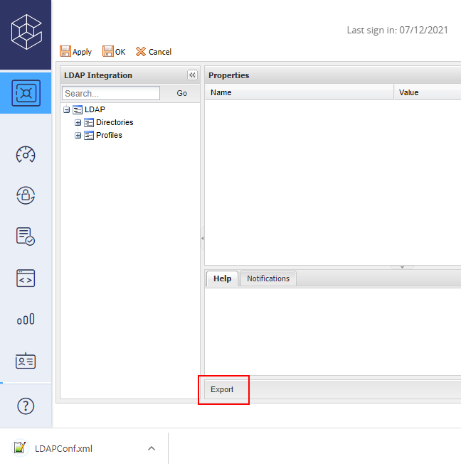

> **Important:** either you use a CSV of XML LDAP configuration you should maintain it, if modification are done on vault LDAP configuration you need to update the CSV file if you use CSV configuration otherwise you need to perform new export of LDAP configuration XML file from CyberArk portal PVWA.

### LDAP extractions ( not from Active Directory )

PAM Booster supports to load data related to accounts, groups and group members using standard LDIF files. If you are using Active Directory, the active directory add-on `bw_activedirectory` provides the script that can handle the data extraction automatically, more information in the next section.

If the data does not come from Active Directory, the LDIF file can be included into the importfile folder and the add-on `bw_ias_ldap` should be installed:

PAM Booster supports LDIF files that use the encoding **ISO-8859-1**.

To identify the **accounts**, entries are filtered by objectclass: user or person or inetorgperson. The ldap attributes that are used for the accounts are:

| Field | LDAP Attribute |
| --- | --- |
| key | dn or distinguishedname |
| Given name | givenname |
| Surname | sn |
| Mail | mail |
| Login | samaccountname or uid or cn |
| Username | displayname or ‘{givenname} {sn}’ if they are not empty, or samaccountname or cn or uid |
| Expire date | loginexpirationtime |

To identify the **groups**, entries are filter by objectclass: group or groupofnames or groupofuniquenames. The ldap attributes that are used for the groups are:

| Field | LDAP Attribute |
| --- | --- |
| Code | dn or distinguishedname |
| Display name | samaccountname or cn or uid |
| Description | description |
| Members | member or uniquemember |

### Active Directory Extractions

PAM Booster requires an extraction of accounts and groups from Active Directory.

The script `ExtractAD.ps1` provided by the add-on `bw_activedirectory` performs the Active Directory extraction. The PowerShell script can be configured to extract several domains.

Only one configuration section is needed to extract Active Directory even if there are multiple domains. The technical account used to run the script must have enough privileges to read the Active Directory content.

Out of the box, the configuration section for Active Directory does not contain information about the credentials to use or the filtering to apply or the domains to extract. There is a list of options to add to the section in order to specify how the Active Directory extraction should be done.

Option

Description

filter

An LDAP filter by default it is: `((objectcategory=Person)(objectclass=group))`

ouFilter

Filter on a specific organizationalUnit, should be a valid organizational Unit DN (example: `OU=Internal Users,DC=intra,DC=test,DC=local`)

**Note**: This filter will apply on all domains if script launched on several servers (with `--server` option).

attributesfile

File that contains the attribute names to include in the extraction (by default, `attributes.cfg`). For example: `attributes.txt` where it contains an attribute in each line for example:

- dn
- objectclass
- accountexpires
- givenname

By default, this option contains the following attribute names:

- objectcategory
- objectguid
- objectsid
- sidhistory
- member
- objectclass
- accountexpires
- badpwdcount
- displayname
- givenname
- lastlogon
- logoncount
- lastlogontimestamp
- mail
- manager
- pwdlastset
- samaccountname
- sn
- whencreated
- useraccountcontrol
- createtimestamp
- description
- grouptype
- managedby
- modifytimestamp
- legacyexchangedn
- PrimaryGroupID

servers

File that contains in each line a name of an AD server, if the file is not specified, the script will extract all the ActiveDirectory domains data in the current forest.

credential

File containing PSCredential used to extract objects in ActiveDirectory, see example to create and store PSCredential object to a file, if not set current session credential will be used.

logLevel

This parameters allow to specify a log level. Possible values are:

- Error
- Warning
- Info
- Debug

The default value is `Error`.

errAction

Specify the action to perform if an error occur. The possible values are:

- Continue
- SilentlyContinue
- Stop

The default value is `Stop`.

port

LDAP server port. The default value is 389.

authType

Authentication method to use in LDAP connection, for more details refer to [https://msdn.microsoft.com/fr-fr/library/system.directoryservices.protocols.authtype(v=vs.110).aspx]

useSSL

Boolean value to activate SecureSocketLayer on LDAP connection. The default value is ‘False’.

© 1995-2023 [Radiant Logic](https://developer.radiantlogic.com/)